# “Is Happiness correlated with openness of data?”

Rupesh Patel

2 October 2018

### Introduction

In this kernal,I will also add another dataset.we will have a look at whether goverments adopt open policies with respect to data sharing are the same countries that score highly on the world happiness index.

Let us hypothesize that two are correlated with each other.so another data I will be using is “2015 global open data Index”.The World Happiness Report is a landmark survey of the state of global happiness

### Getting Started with data exploration

```r
#Necessary Packages

library(ggplot2)
library(dplyr)
library(stringr)
library(formattable)
library(ggthemes)
library(corrplot)


#Importing data set

happiness <- read.csv('2017.csv',stringsAsFactors = F)
openness  <- read.csv('countries.csv',stringsAsFactors = F)


#Exploring data set

str(happiness)
```

```
## 'data.frame':    155 obs. of  12 variables:
##  $ Country                      : chr  "Norway" "Denmark" "Iceland" "Switzerland" ...
##  $ Happiness.Rank               : int  1 2 3 4 5 6 7 8 9 10 ...
##  $ Happiness.Score              : num  7.54 7.52 7.5 7.49 7.47 ...
##  $ Whisker.high                 : num  7.59 7.58 7.62 7.56 7.53 ...
##  $ Whisker.low                  : num  7.48 7.46 7.39 7.43 7.41 ...
##  $ Economy..GDP.per.Capita.     : num  1.62 1.48 1.48 1.56 1.44 ...
##  $ Family                       : num  1.53 1.55 1.61 1.52 1.54 ...
##  $ Health..Life.Expectancy.     : num  0.797 0.793 0.834 0.858 0.809 ...
##  $ Freedom                      : num  0.635 0.626 0.627 0.62 0.618 ...
##  $ Generosity                   : num  0.362 0.355 0.476 0.291 0.245 ...
##  $ Trust..Government.Corruption.: num  0.316 0.401 0.154 0.367 0.383 ...
##  $ Dystopia.Residual            : num  2.28 2.31 2.32 2.28 2.43 ...
```

```r
str(openness)
```

```
## 'data.frame':    149 obs. of  8 variables:
##  $ Country.Code: chr  "TW" "GB" "DK" "CO" ...
##  $ Country.Name: chr  "Taiwan" "United Kingdom" "Denmark" "Colombia" ...
##  $ X2015.Rank  : int  1 2 3 4 5 5 7 8 8 10 ...
##  $ X2015.Score : int  78 76 70 68 67 67 66 64 64 63 ...
##  $ X2014.Rank  : int  11 1 2 12 4 5 13 8 17 7 ...
##  $ X2014.Score : int  67 97 83 66 73 72 66 70 64 71 ...
##  $ X2013.Rank  : int  36 1 2 61 7 9 61 2 5 4 ...
##  $ X2013.Score : int  42 94 87 0 72 66 0 87 74 76 ...
```

```r
#To check for unique rows using pipe operator
happiness %>%
group_by(Country) %>%
mutate(n = n()) %>%
filter(n > 1)
```

```
## # A tibble: 0 x 13
## # Groups:   Country [0]
## # ... with 13 variables: Country <chr>, Happiness.Rank <int>,
## #   Happiness.Score <dbl>, Whisker.high <dbl>, Whisker.low <dbl>,
## #   Economy..GDP.per.Capita. <dbl>, Family <dbl>,
## #   Health..Life.Expectancy. <dbl>, Freedom <dbl>, Generosity <dbl>,
## #   Trust..Government.Corruption. <dbl>, Dystopia.Residual <dbl>, n <int>
```

```r
openness %>%
group_by(Country.Name) %>%
mutate(n = n()) %>%
filter(n > 1)
```

```
## # A tibble: 0 x 9
## # Groups:   Country.Name [0]
## # ... with 9 variables: Country.Code <chr>, Country.Name <chr>,
## #   X2015.Rank <int>, X2015.Score <int>, X2014.Rank <int>,
## #   X2014.Score <int>, X2013.Rank <int>, X2013.Score <int>, n <int>
```

```r
#correcting error for Russia country
openness$Country.Name[62] <- "Russia"

#changing coloum names

colnames(openness)[2] <- "Country"

#Joining two data table by "Country"

open_happy <- happiness %>%
              left_join(openness,by = "Country") %>%
              mutate(Country = factor(Country)) %>%
              select(Country,Happiness.Score,X2015.Score,Economy..GDP.per.Capita.,Family,Health..Life.Expectancy.,Freedom,Generosity,Trust..Government.Corruption.,Dystopia.Residual)

#changine Colnames to better names

colnames(open_happy) <- c("country","happiness","openness","gdp","family","health","freedom","generosity","goverment","dyst_residual")


#checking NAs for `openness`
sum(is.na(open_happy$openness))
```

```
## [1] 39
```

Now that I have the data roughly how I want it, let’s have a quick peek. I really like this package called [`formattable`](https://github.com/renkun-ken/formattable) for presenting information in dataframes. Let’s use it to look at the characteristics of the top 10 countries with the highest scores for their open data sharing policies:

```r
#making nice table to get relationship between happiness and openness
library(formattable)

open_happy %>%
  arrange(desc(openness)) %>%
  mutate_each(funs(round(., 2)), -c(country,openness)) %>%
  head(10) %>%
  formattable(list(
    openness = color_bar("yellow"),
    happiness = color_bar("lightgreen"),
      gdp = color_bar("deepskyblue"),
    family = color_bar("deepskyblue"),
    health = color_bar("deepskyblue"),
    freedom = color_bar("deepskyblue"),
    goverment = color_bar("deepskyblue"),
    generosity = color_bar("deepskyblue"),
    dyst_residual = color_bar("deepskyblue")
  ), align = "l")
```

| country | happiness | openness | gdp | family | health | freedom | generosity | goverment | dyst_residual |
| --- | --- | --- | --- | --- | --- | --- | --- | --- | --- |
| United Kingdom | 6.71 | 76 | 1.44 | 1.50 | 0.81 | 0.51 | 0.49 | 0.27 | 1.70 |
| Denmark | 7.52 | 70 | 1.48 | 1.55 | 0.79 | 0.63 | 0.36 | 0.40 | 2.31 |
| Colombia | 6.36 | 68 | 1.07 | 1.40 | 0.60 | 0.48 | 0.15 | 0.05 | 2.62 |
| Finland | 7.47 | 67 | 1.44 | 1.54 | 0.81 | 0.62 | 0.25 | 0.38 | 2.43 |
| Australia | 7.28 | 67 | 1.48 | 1.51 | 0.84 | 0.60 | 0.48 | 0.30 | 2.07 |
| Uruguay | 6.45 | 66 | 1.22 | 1.41 | 0.72 | 0.58 | 0.18 | 0.18 | 2.17 |
| Netherlands | 7.38 | 64 | 1.50 | 1.43 | 0.81 | 0.59 | 0.47 | 0.28 | 2.29 |
| United States | 6.99 | 64 | 1.55 | 1.42 | 0.77 | 0.51 | 0.39 | 0.14 | 2.22 |
| Norway | 7.54 | 63 | 1.62 | 1.53 | 0.80 | 0.64 | 0.36 | 0.32 | 2.28 |
| France | 6.44 | 63 | 1.43 | 1.39 | 0.84 | 0.47 | 0.13 | 0.17 | 2.01 |

Alas!! table suggests that our hypothesis might be true. There is a clear relationship between `Openness` and `hapiness`.

### Are open countries happy countries?

Now,we are going to visualize this relationship with the help of linear regression model. we will `3` groups of countries.

- **G8** : This refers to the group of eight highly industrialized nations
- **BRICS**: It isthe acronym coined for an association of five major emerging national economies: Brazil, Russia, India, China and South Africa
- **ASEAN**: This is the Association of Southeast Asian Nations has 10 member states, one candidate member state, and one observer state.

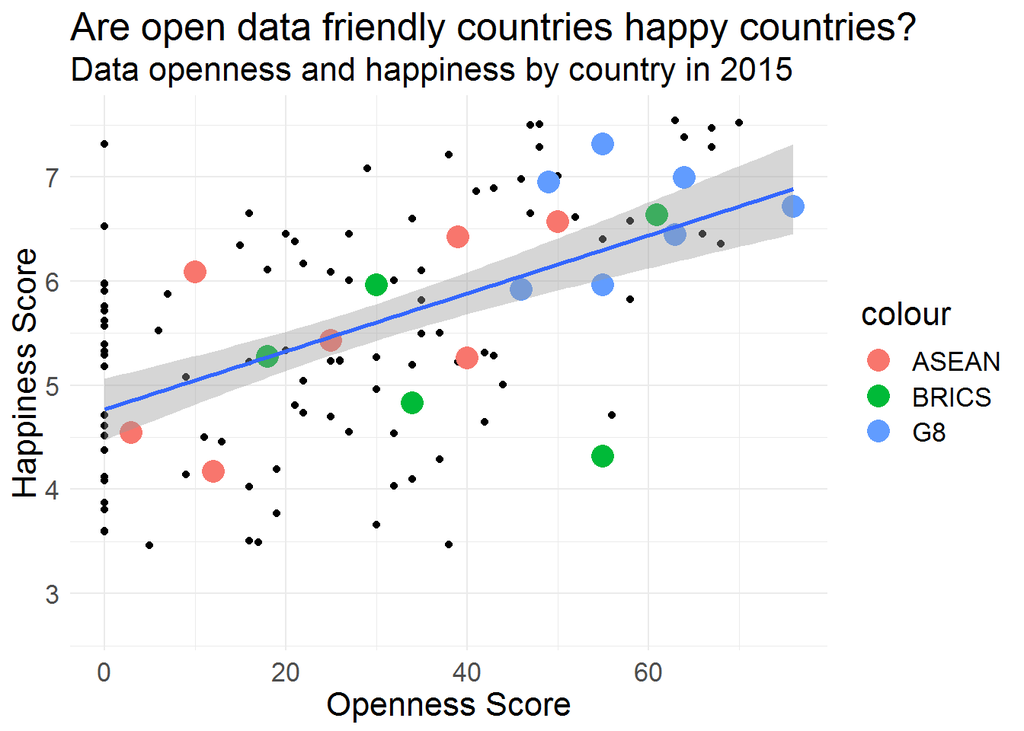

```r
#countries group

g8 <- c("Canada","France","Germany","Italy","Japan","United Kingdom","United States","Russia")
brics <- c("India","China","South Africa","Brazil","Russia")
asean <- c("Brunei", "Cambodia", "Indonesia", "Laos", "Malaysia", "Myanmar","Philippines", "Singapore", "Thailand","Vietnam")

#some changes for plotting the graph
rownames(open_happy) <- open_happy$country

#Is Happiness related with openness?

ggplot(open_happy,
       aes(x = openness,
           y = happiness)) +
  geom_point() +
  geom_point(data = open_happy[g8,],aes(colour = "G8"),size = 5) +
  geom_point(data = open_happy[brics,],aes(colour = "BRICS"),size = 5) +
  geom_point(data = open_happy[asean,],aes(colour = "ASEAN"),size = 5) +
  geom_smooth(method="lm") +
  labs(x = "Openness Score",
       y = "Happiness Score",
       title = "Are open data friendly countries happy countries?",
       subtitle = "Data openness and happiness by country in 2015") +
    theme_minimal() +
  theme(text = element_text(size=16))
```

It looks like that most off **G8** countries are more happier and open about their data than **ASEAN,BRICS** group countries.

### What other measures are correlated with “Openness”?

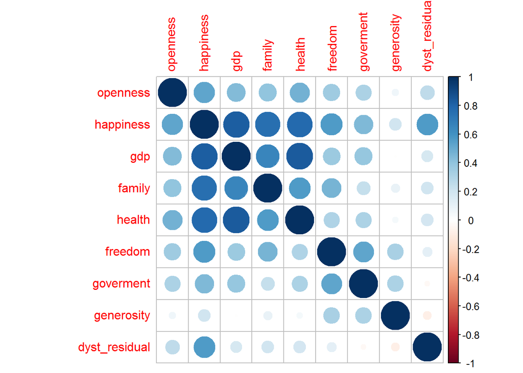

```r
open_data_corr <- open_happy %>%
  select(openness, happiness, gdp, family, health,
         freedom,goverment,generosity, dyst_residual) %>%
  mutate(openness = as.numeric(openness))

od_corr <- cor(open_data_corr, use = "complete", method = "pearson")

corrplot(od_corr)
```

Hope you enjoyed this analysis between datas from different sources.